# CS166 Assignment 2

## 2019 October 14

# Single-lane road

```python
import numpy as np
from matplotlib import pyplot as plt
class TrafficSimulation:

    def __init__(self, length=100, density=0.3, p=0.5, max_speed=5):
        self.road_length = length #size
        self.density = density #initial car density
        self.max_speed = max_speed #cap on speed
        self.p = p #prob cars will slow down at a update
        self.flow=0 #flow counter

        ind_rand = np.random.choice(range(self.road_length)
                                    ,size=int(round(self.density * self.road_length)), replace=False)
        self.state = -np.ones(self.road_length, dtype=int)  # -1 means empty cell
        self.state[ind_rand] = np.random.randint(0, self.max_speed + 1, size=len(ind_rand))

    def update(self, show=True):
        for i in range(self.road_length):
            if self.state[i] != -1: #if car
                dist = 1
                while self.state[(i + dist) % self.road_length] == -1:
                    dist += 1
                #accelerate
                if self.state[i] < self.max_speed:
                    self.state[i] += 1
                #slow down
                if self.state[i] >= dist:
                    self.state[i] = dist -1
                #random slow down
                if (self.state[i] > 0) and (np.random.uniform() < self.p):
                    self.state[i] -= 1
                #count flow
                if self.state[i]+i>=self.road_length:
                    self.flow+=1

        if show:
            self.show()
        #create and write new state
        new_state = -np.ones(self.road_length, dtype=int)
        for i in range(self.road_length):
            if self.state[i] != -1:
                new_state[(i + self.state[i]) % self.road_length] = self.state[i]
        self.state = new_state

    def show(self):
        print(''.join('.' if x == -1 else str(x) for x in self.state))
```

## Visualisation of Traffic at Different Densities

```python
# function for running sim multiple times
def run_sim(length=100, density=0.3, p=0.5, max_speed=5,show=False, obj=False,n=50):
    sim = TrafficSimulation(length, density, p)
    for _ in range(n):
        sim.update(show)
    #return object if needed
    if obj:
        return sim
```

### Density = 0.1

```python
run_sim(density=0.1,show=True)
```

```
....................................1.4.......0....1...2..04........1...................01..........
.....................................2....2...0.....1....00....5.....2..................0.1.........
.......................................3....0.0......1...01.........1..2................1..1........
..........................................1.1.0.......2..0.1.........2...3...............2..2.......
...........................................0.01.........00..1..........2....4..............2..2.....
...........................................0.1.1........01...1...........2......4............2..3...
...........................................0..0.2.......0.1...1............2........4..........2...3
..4........................................1..1...2.....1..2...1.............3..........4........2..
......4.....................................2..1....2....2...2..1...............3...........4......2
.2........4...................................0.2.....3....2...1.1.................4............4...
1..2..........5...............................0...3......2...2..1.2....................5............
.2...3.............4..........................1......3.....2...1.2..2.......................5.......
...2....3..............4.......................2........3....2..1..2..2..........................4..
.2...3.....4...............5.....................2.........2...1.1...1..2...........................
...2....3......4................5..................2.........1..1.2...1...2.........................
.....2.....4.......4.................5...............2........1..1..2..1....2.......................
.......2.......5.......5..................5............3.......1..1...1.1.....3.....................
.........2..........4.......5..................4..........4.....1..2...0.2.......4..................
...........2............5........4.................5..........1..1...0.0...3.........4..............
.............2...............5.......4..................5......1..1..1.0......3..........4..........
...............3..................5......4...................1..1..1..01.........4...........4......
..................4....................5.....5................1..1..1.1.1............4...........4..
.4....................5.....................4.....4............1..2..1.0.1...............4..........
.....4.....................5....................4.....5.........1...0.00..1..................4......
.........5......................5...................5......4.....2..0.01...2.....................5..
..5...........5......................5...................5.....3...00.1.1....3......................
.......5...........4......................5...................3...000..1.1......4...................
............5..........5.......................4.................0000...1.1.........4...............
.................4..........4......................5.............0001....1.2............4...........
.....................4..........5.......................5........001.2....1..2..............4.......
.........................4...........4.......................3...00.2..2...2...3................5...
.5...........................5...........5......................000...1..2...3....4.................
......4...........................4...........4.................001....1...2....3.....5.............
..........5...........................4...........5.............01.2....2....3.....3.......4........
...............4..........................5............5........0.2..3....2.....4.....4........5....
5..................4...........................5............2...1...2...2...2.......5.....4.........
.....5.................5............................5.........2..2....2...3...2..........4....4.....
..........4.................4............................5......2..3....3....1..2............4....5.
...4..........4.................5.............................3...2...3....2..2...2..............4..
.4.....4..........4..................4...........................2..2....3...1..3...2...............
.....5.....4..........4..................5.........................1..2.....0.1....1..2.............
..........4....5..........5...................4.....................2...3...1..2....1...2...........
..............5.....4..........4..................5...................2....1.2...2...2....3.........
...................3....4..........4...................4................2...1..3...2...2.....3......
......................3.....5..........4...................4..............1..1....1..2...3......4...
4........................3.......4.........5...................5...........2..1....1...2....4.......
....5.......................3........4..........5...................5........1.2....1....3......4...
4........5.....................3.........5...........5...................4....2..3...2......3.......
....5.........5...................3...........5...........4..................1..3...1..2.......4....
.........5.........5.................3.............5..........4...............2....1.2...3.........5
```

### Density = 0.5

```python
run_sim(density=0.5,show=True)
```

```
1.3...0.0.001..0001..2...01.0000001..3...5.....2..3...01.....1..001.000000.01..01.2....00002....01.0
.2...00.0.01.1.000.1...1.1.0000001.2....4.....1..3...00.1.....1.00.0000001.0.1.0.2..1..0001..2..0.00
...0.00.1.1.1.0001..2...1.0000001.1..3......2..1....001..2.....001.000001.00..00...1.1.000.2...01.01
1..0.00..0.1.0000.1...1..0000000.0.1....4.....1.2...00.2...3...01.000001.001..00....0.0001...0.1.01.
.1.1.00..1..00001..1...1.0000000.1..1.......1..1..0.00...2....00.000001.001.1.01....0.001.1..0..00.0
..1.000...1.0000.1..1...00000001..2..1.......2..0.1.01.....2..00.00001.000.1.00.1...1.00.0.0.0..01.0
...0001....00000..1..2..0000001.2...1.2........01..01.1......000.0000.0000..000..1...000.0.0.0..1.00
...000.1...00000...2...0000001.1..2..1..2......1.1.1.0.2.....000.0001.0001..001...1..000.1.0.0...000
...000..2..00001.....1.000000.0.2...1.1...3.....1.0.01...2...000.001.0001.0.00.2...1.001..00.0...000
...001....00000.1.....0000000.1...1..1.2.....2...00.0.2....1.001.00.0001.01.01...1..000.0.00.1...001
2..01.1...00000..2....0000000..2...1..1..3.....1.00.0...3...000.001.001.00.01.2...0.000.1.00..1..01.
..01.1.1..00001....2..0000001....1..1..1....2...001.1......0001.01.000.000.0.2..1.1.001..001...0.1.1
0.1.0.0.0.0000.1.....0000001.1....2..2..1.....0.00.1.2.....000.00.0000.000.0...0.1.001.0.01.2..1..1.
0..00.0.0.0000..1....000000.1.1.....1..1.2....1.01..1..3...001.01.0001.001.0...0..000.01.1.1..0.1..0
0..00.1.1.0000...2...000000..1.1.....1..2..3...01.2..2....001.00.0000.000.01...0..000.0.0.0.1.0..1.0
0..01..0.00001.....0.000000...0.2.....2...2...01.1..1..2..00.000.0000.001.1.2..1..001.1.0.1..01...00
1..1.0.1.0001.2....0.000000...1...2.....3...1.0.1.1..2...001.000.0001.00.1.1..0.0.01.0.01..0.0.1..00
.2..01..0001.2..1..0.000000....1....2......0.00..0.2...0.01.0001.000.000..1.1.0.1.1.01.1.0.1.0..0.01
2..00.0.000.1..0.1.1.000001.....2.....3....1.01..0...1.1.0.0001.0001.001...1.01..1.00.1.00..00..1.1.
..001.0.001..1.1..1.000000.1......3......2..01.0.1....1.01.000.0000.001.2...01.2..001..000..00...0.1
1.00.01.00.2..1.1..0000001..2........4.....01.00..1....01.0001.0000.01.2..0.0.1..001.1.000..00...1..
.000.0.001...0.1.1.000001.1...2..........1.1.001...1...1.0000.00001.0.1..00.0..0.00.0.0000..01....1.
.000.1.00.2..0..0.000000.1.2....2.........1.000.1...1...00001.0000.01..0.00.1..1.01.0.0000..0.1....0
.001..001...01..1.000001..1..3....2........0001..1...2..0001.00000.1.1.0.00..2..00.00.0000..1..1...1
000.0.00.1..1.1..000001.2..1....2...2......000.1..1....0000.000000..0.01.01....001.00.0000...1..1...
001.1.00..2..1.0.00000.2..1.2.....3...2....001..1..1...0001.000000..1.0.00.1...00.001.0000....1..2..
00.0.000....0.01.00000...0.1..2......1..1..01.1..2..2..001.0000001...01.01..1..01.01.00000.....1...0
00.0.001....0.1.000000...1..1...3.....1..1.0.0.2...2..000.0000000.1..0.00.2..1.1.01.000000......1..0
01.1.01.2...0..0000001....2..2.....2...1..01.0...3...0001.0000000..0.0.01...1.0.00.0000000.......1.0
1.0.01.1..1.0..000001.2.....1..3.....2..1.1.00......0001.00000000..1.0.1.1...00.01.0000001........00
.01.0.0.1..01..00001.2..2....1....4....1.0.001......001.000000001...01..0.2..01.0.0000001.1.......01
00.01.0..1.0.0.0001.1..2..3...2.......1.00.01.2.....00.000000000.1..0.0.0...01.00.000000.1.2......1.
01.0.00...00.0.000.0.1...2...1..3......001.1.1..3...00.000000001..0.0.0.1...1.000.000000..1..3.....0
0.01.01...00.0.000.1..1....1..1....3...01.1.1.1....000.00000000.1.0.1.0..2...0000.000001...1....1..0
0.1.00.1..01.0.000..1..2....2..1......01.0.1.0.2...000.00000000..01..00....0.0000.00000.1...1....1.0
1..000..0.0.01.000...1...3....1.2.....1.01..00...1.001.00000001..0.1.00....1.0001.00001..1...2....00
.0.000..1.1.0.0000....1.....1..1..2....01.1.00....000.00000000.0.0..000.....0000.00001.2..2....1..00
.1.000...0.01.0001.....1.....1..2...1..1.1.001....001.00000001.0.0..000.....0000.0001.1..1..3...0.01
1.0000...1.1.0001.2.....1.....1...2..1..0.000.2...00.00000001.00.0..001.....0001.001.1.1..2....01.0.
.00001....0.0001.2..3....2.....2....1.0.0.001...1.01.0000001.000.1..01.2....000.001.0.1.2...1..1.01.
.0001.2...1.001.1..2...2...3.....3...00.0.00.1...01.0000001.0000..0.0.2..1..001.01.00..1..2..1..01.0
.000.2..2..000.0.1...2...2....3.....000.0.00..2..1.0000000.00001..0.1...0.1.00.00.001...2...1.0.0.01
0001...1..0000.0..1....3...2.....1..000.0.00....0.00000000.0000.1.0..2..0..001.01.00.2....2..00.0.1.
000.2...0.0000.1...2......2..2....0.001.0.01....1.00000000.0001..01....01..00.01.000...3....001.0..0
001...0.0.0001..2....3......2..1..0.01.00.0.1....000000001.000.1.0.1...1.1.01.1.0001......0.01.01..0
01.1..0.0.001.2...3.....4.....0.0.1.0.000.0..2...00000001.0000..00..2...0.01.1.0001.2.....0.1.01.1.0
0.0.0.1.1.01.2..3....4......0.1.1..00.000.1....0.0000001.00000..00....1.0.0.0.0000.2..3...0..00.0.00
1.0.0..1.01.2..2...3.....2..0..0.0.01.000..2...1.000001.000001..00.....01.1.0.0001...2...00..00.1.00
.00.0...00.2..2..3....4....00..1.0.0.0000....1..000001.000001.0.00.....0.1.01.001.2....0.00..01..000
.00.1...00...2..3...3.....000...01.1.0001.....1.00001.000000.00.01.....1..00.000.1..1..0.00..1.1.000
```

### Density = 0.9

```python
run_sim(density=0.9,show=True)
```

```
000000000000001.0000000000000.00000.0000000000000000000000.000.000000000000.0000000.0001.0001..00000
00000000000001.00000000000000.00000.0000000000000000000000.001.000000000001.0000001.001.0000.1.00000
0000000000000.000000000000001.00001.0000000000000000000001.01.000000000001.0000001.000.00000..000000
0000000000001.00000000000001.00000.0000000000000000000001.01.000000000000.0000001.0000.00000..000000
000000000000.00000000000000.000001.000000000000000000001.00.0000000000001.000000.00001.00000..000000
000000000000.00000000000000.00000.000000000000000000001.001.000000000000.0000001.0000.000000..000000
000000000000.00000000000001.00001.00000000000000000001.001.0000000000001.000000.00000.000001..000000
000000000000.0000000000000.00000.00000000000000000000.001.0000000000000.0000000.00000.00000.1.000000
000000000000.0000000000000.00000.00000000000000000001.01.00000000000000.0000000.00001.00000..0000000
000000000000.0000000000000.00000.0000000000000000000.00.000000000000001.0000001.0001.000001..0000000
000000000000.0000000000001.00000.0000000000000000000.01.00000000000001.0000001.0000.000000.1.0000000
000000000001.000000000000.000000.0000000000000000000.0.00000000000001.0000001.00000.000000..00000000
00000000001.0000000000001.000001.0000000000000000000.1.0000000000000.0000000.000000.000000..00000000
0000000001.0000000000000.000001.00000000000000000000..00000000000001.0000001.000000.000001..00000000
000000000.00000000000001.00001.000000000000000000000..0000000000001.0000001.0000001.00001.0.00000000
000000000.0000000000000.00000.0000000000000000000000..000000000001.0000001.0000000.00000.01.00000000
000000001.0000000000000.00000.0000000000000000000000..00000000000.0000001.00000001.00001.1.000000000
00000000.00000000000001.00000.0000000000000000000000..00000000001.000001.00000000.00001.1.0000000000
00000000.0000000000001.000000.0000000000000000000001..0000000000.000000.000000001.0000.1.00000000000
00000000.000000000000.0000001.000000000000000000001.0.0000000001.000000.00000001.00000..000000000000
00000000.000000000000.000001.000000000000000000000.01.000000001.0000000.0000000.000001..000000000000
00000001.000000000000.00000.0000000000000000000000.0.000000000.00000001.0000000.00000.0.000000000000
0000000.0000000000000.00001.0000000000000000000000.0.000000000.0000001.00000001.00000.1.000000000000
0000001.0000000000000.0001.00000000000000000000000.0.000000001.000001.00000000.000000..0000000000000
000000.00000000000001.000.000000000000000000000001.0.00000000.000001.000000000.000001..0000000000000
000001.0000000000000.0000.00000000000000000000000.00.00000000.00001.0000000001.00000.1.0000000000000
00000.00000000000001.0001.00000000000000000000001.00.00000000.0001.0000000001.000000..00000000000000
00000.0000000000001.0000.00000000000000000000001.000.00000001.001.0000000001.0000000..00000000000000
00001.000000000000.00001.0000000000000000000001.0000.0000001.001.0000000001.00000001..00000000000000
0001.0000000000000.0001.0000000000000000000001.00000.000000.001.0000000001.00000001.1.00000000000000
000.00000000000001.001.0000000000000000000000.000000.000001.00.0000000001.00000000.1.000000000000000
001.0000000000000.001.00000000000000000000001.000001.00000.001.000000001.000000001..0000000000000000
00.00000000000001.00.00000000000000000000000.000000.000001.01.000000000.000000000.0.0000000000000000
01.0000000000001.000.00000000000000000000001.000001.00001.01.0000000000.000000000.1.0000000000000000
1.0000000000000.0001.0000000000000000000000.000001.00000.01.00000000000.000000000..00000000000000000
.00000000000000.000.00000000000000000000001.00001.000001.1.000000000001.000000000..00000000000000000
.00000000000000.001.0000000000000000000000.00001.000001.1.000000000001.0000000001..00000000000000000
.00000000000001.01.00000000000000000000001.0001.000000.1.000000000001.0000000001.1.00000000000000001
00000000000000.00.00000000000000000000000.0001.0000001..000000000001.0000000001.0.00000000000000000.
00000000000000.00.00000000000000000000000.001.0000001.1.00000000000.0000000001.00.00000000000000000.
00000000000000.00.00000000000000000000001.00.0000001.0.000000000001.000000001.000.00000000000000000.
00000000000001.01.0000000000000000000001.001.000000.00.00000000001.000000000.0001.00000000000000000.
0000000000001.01.0000000000000000000000.000.0000001.00.0000000001.0000000000.000.000000000000000001.
000000000000.01.00000000000000000000001.000.000000.000.000000000.00000000000.001.00000000000000001.0
000000000000.1.00000000000000000000001.0001.000000.001.000000000.00000000001.01.00000000000000001.00
000000000000..00000000000000000000000.0001.0000000.00.0000000001.0000000000.01.00000000000000000.000
000000000001..00000000000000000000001.000.00000001.01.000000000.00000000000.1.000000000000000000.000
00000000000.0.0000000000000000000000.0001.0000001.01.0000000001.00000000001..0000000000000000001.000
00000000000.0.0000000000000000000001.001.0000001.01.0000000001.00000000001.1.000000000000000000.0000
00000000000.1.000000000000000000000.000.0000001.00.0000000001.00000000000.0.0000000000000000001.0000
```

### How do traffic jams form?

Traffic jams are the consequence of the stochastic process of slowing-down. Parameter $p$ determines the probability with which a single car might decrease its velocity by 1. When this happens, cars behind the slowing down car need to slow down, initiating a chain reaction of slowing down in cars further down.

Traffic jams may be identified on the above visualisations as a string of zeros, indicating motionless cars. Jams travel in shockwaves in a backwards direction. This can be best seen on the visualisation at $density=0.5$.

### Overall traffic flow as a function of density

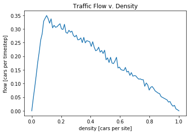

```python
densities=np.linspace(0,1,100) #array of different densities from 0 to 1
flow=[]#strorage vector for flow
#loop through all densities multiple times, average flow, plot results
for d in densities:
    flow_temp=[]
    for j in range(100):
        sim=run_sim(density=d, show=False, obj=True,n=100)
        flow_temp.append(sim.flow/100)
    flow.append(np.mean(flow_temp))
plt.plot(densities,flow)
plt.title("Traffic Flow v. Density")
plt.xlabel("density [cars per site]")
plt.ylabel("flow [cars per timestep]")
plt.show()
```

The above graph is the visualisation of traffic flow at differen initial densities. The simulation was run for $10^4$ steps for $100$ different densities between $0$ and $1$.

As we can see on the graph, traffic flow steadily increases to the point, where $density=0.1$, and gradually decreases to a halt until $density=1$.

# Two-lane Highway

## Assumptions

The two-lane model is an extension of the single lane model, with the additional feature of cars being able to change lanes. The update rules for moving forward stayed the same, and additional rules for changing lanes were added.

I assumed that (unlike in real life) there are no such rules as "keeping right" or "keeping left". Thus, lane changes only happen so for cars to avoid jams. Also, cars in both lanes are going in the same direction.

## Parameters

The parameters of the model stayed the same as for the single model. The simulation can still be initialised to different road lengths, car densities, max speeds, and probabilities of slow down.

In contrast to the single-lane model, keeping track of the traffic flow has changed. Instead of measuring the total flow, an average of flow is calculated between left and right lanes, so as to give us results that are comparable to single-lane traffic results.

## Update Rules

As the update rules for moving forward stayed the same as in the single lane model, the only additional update rules concerned the changing of lanes. The rules to this update are (for further details, see comments in code):

1. Check if car ahead in the same lane would necessitate slow-down. If yes, proceed.
2. Check if car ahead in the next lane would necessitate slow-down. If no, proceed.
3. Check if changing lanes would necessitate cars in the other lane to slow down. If no, proceed.
4. Change Lanes.

The simulation is carried out in two steps. First, the lane changes are actions and then the original forward moving rules come. While, it might seem counterintuitive to split the process into two steps, but in effect the results are the same.

```python
class TrafficSimulation2:

    def __init__(self, L=100, car_dens=0.3, prob_slow=0.5, max_speed=5, flow=0):
        self.length = L #size
        self.car_dens = car_dens #initial car density
        self.max_speed = max_speed #cap on speed
        self.prob_slow = prob_slow #prob cars will slow down at a step
        self.flow = 0
        self.balance = []

        #random indices for state initialisation
        init_ind1 = np.random.choice(range(self.length)
                                     ,size=int(round(self.car_dens * self.length)), replace=False)
        init_ind2 = np.random.choice(range(self.length)
                                     ,size=int(round(self.car_dens * self.length)), replace=False)

        #set up left lane
        self.state_left=-np.ones(self.length,dtype=int)
        self.state_left[init_ind1]=np.random.randint(0,self.max_speed+1,size=len(init_ind1))

        #set up right lane
        self.state_right=-np.ones(self.length,dtype=int)
        self.state_right[init_ind2]=np.random.randint(0,self.max_speed+1,size=len(init_ind2))


    def update_right(self,lane):
        #function carrying out rules from Part 1
        for i in range(self.length):
            if lane[i] != -1: #if car, i.e. not empty
                dist = 1
                while lane[(i + dist) % self.length] == -1:
                    dist += 1
                if lane[i] < self.max_speed:
                    lane[i] += 1
                if lane[i] >= dist:
                    lane[i] = dist - 1
                if (lane[i] > 0) and (np.random.uniform() < self.prob_slow):
                    lane[i] -= 1

        new_state = -np.ones(self.length, dtype=int)
        for i in range(self.length):
            if lane[i] != -1:
                new_state[(i + lane[i]) % self.length] = lane[i]
        self.state_right = new_state

    def update_left(self,lane):
        #function carrying out rules from Part 1
        for i in range(self.length):
            if lane[i] != -1: #if car, i.e. not empty
                dist = 1
                while lane[(i + dist) % self.length] == -1:
                    dist += 1
                if lane[i] < self.max_speed:
                    lane[i] += 1
                if lane[i] >= dist:
                    lane[i] = dist - 1
                if (lane[i] > 0) and (np.random.uniform() < self.prob_slow):
                    lane[i] -= 1

        new_state = -np.ones(self.length, dtype=int)
        for i in range(self.length):
            if lane[i] != -1:
                new_state[(i + lane[i]) % self.length] = lane[i]
        self.state_left = new_state

    def step(self, show=True):
        #left lane
        for i in range(self.length):
            if self.state_left[i] != -1 and self.state_right[i]== -1: #if car but other lane empty
                #other car in the way?
                dist = 1
                while self.state_left[(i + dist) % self.length] == -1:
                    dist += 1
                if self.state_left[i] >=dist:
                    #check if space ahead in other lane
                    dist=1
                    while self.state_right[(i + dist) % self.length] == -1:
                        dist += 1
                    if self.state_left[i] <= dist:
                        #check if car behind in other lane has speed lower than where car would move
                        index=-1
                        while self.state_right[(i + index) % self.length] == -1:
                            index-=1
                        if self.state_right[i+index]-abs(index)<self.state_left[i]:
                            #move car to other lane
                            self.state_right[i]=self.state_left[i]
                            self.state_left[i]=-1

        #right lane
        for i in range(self.length):
            if self.state_right[i] != -1 and self.state_left[i]== -1: #if car but other lane empty
                #other car in the way?
                dist = 1
                while self.state_right[(i + dist) % self.length] == -1:
                    dist += 1
                if self.state_right[i] >=dist:
                    #check if space ahead
                    dist=1
                    while self.state_left[(i + dist) % self.length] == -1:
                        dist += 1
                    if self.state_right[i] <= dist:
                        #check if car behind has speed lower than where car would move
                        index=-1
                        while self.state_left[(i + index) % self.length] == -1:
                            index-=1
                        if self.state_left[i+index]-abs(index)<self.state_right[i]:
                            #move car to other lane
                            self.state_left[i]=self.state_right[i]
                            self.state_right[i]=-1

        #update both lanes according rules of one-lane simulation
        self.update_left(self.state_left)
        self.update_right(self.state_right)

        #update flow
        for k in range(5):
            if self.state_left[-k]+(self.length-k)>self.length:
                self.flow+=1
            if self.state_right[-k]+(self.length-k)>self.length:
                self.flow+=1

        #calculate balance
        self.balance.append((100-np.count_nonzero(self.state_left == -1))
                            /(100-np.count_nonzero(self.state_right == -1)))


        #display
        if show:
            self.show()

    def show(self):
        print(''.join('.' if x == -1 else str(x) for x in self.state_left))
        print(''.join('.' if x == -1 else str(x) for x in self.state_right))
        print('')
```

```python
# function for running sim multiple times
def run_sim2(length=100, density=0.3, p=0.5, max_speed=5,show=False, obj=False,n=50):
    sim = TrafficSimulation2(length, density, p)
    for _ in range(n):
        sim.step(show)
    #return object if needed
    if obj:
        return sim
```

## Visualisation of two-lane model at different densities

### Density = 0.3

```python
run_sim2(show=True, p=0.3, n=20)
```

```
.1.....30...3.10.1....300.....0.1.1.0...3........2..20..2.1...1..0.1..2.....5......3....2.0...2.0..2
...3..00000.....4.100....4......2.1.1.1...2...........3....4......0...3..1.....2.0.0...3....1..00..2

1.1..2.00.....00.0..2..00.....0..1.1.1......4.......30...3..2...2.1.1....3.......5.....4.1.1...1.1..
..3...00000....3.1.0.1..2.....5.0..1.1.1.....3.........3.1......5..1...1..1....0..1.1......4..20.1..

0..1..10.1....00..1...20.1.....1.0..1.1.........4....0....1....30..1..2......4........5...1.1...1..2
.....300000....0..1.1..2...3...10...1.1.1........4...1..1..2......2..2...2..2...1.0...2..2...20.1..2

.1..1.0.1.1...0.1...2.0.1.1.....1.1..1.1........0...3.1.....2....1...2..2........4.......30.0.1...20
.2...000000.....1..1.1....3...300....10..1.............2..2...3..2.1....3..2...30..1...1....3..1.1..

1..2.1.1.1..2..1..2..10.0...2...0...20...2.......1......2....1.1..1....2...3.........4.....1.1.1.0..
2...300000.1......2.1..2.....3000....00...1...........2.1....3....1..2....2...300....2.0...2.1...2..

..2.1.1.1..2..2..2.1.10.0...0..20...0.1.....3.....1....1...3.0...2..2.....3..2....4.......5.1.1.1.1.
..2.000000..1.......2.1...3...00.1...0.1...1.............1.......4..2...3....3.0.1....1.1..0..1....2

..0..1.1..2..2...3..100.0....1.0.1...1..2.......4..1.....2....1....2...3.1..2..2.......5...1.1.1.1.1
.20.000000....2...1..1.1.....30.1..2.0...2...2............1....4...2...3......1.1..2...1.1.0....2...

1..1..1.1...2..2...200.1.1....1.1.10..1...2..........2......3.0..2....30...2..2...3.......3.1.1.10..
.00.000000.......3..20...2...0.1.1....1.....3.1......5.....1..........3....4...1.1....30..1.1.....2.

..2.1..1.1...1...2.000..1..2..0.0.10....2..1....4.......3....2.1....3.0.1...1....3...3..2..1.1..20..
200.000000.........200......30..1...2..1........2.........5.....4........3....30...2....1..1.1...1..

0..1..2.1..2...2..100.1..1..1.0..1..1....1...2.......5.....3.0.0.....50..1..0...20.0...2..2.1.1.0.1.
.00.00000.1........000......0.1.0.0...2..2.........3..........4.........4....4.0..........2.1..2..1.

0...1..1.1....3..200.1.1..1..1.1..1...2....2....3.........5...10.....00....20...3.1.1....2.1.10..1.1
20.10000.1..2......00.1......1.10..1....2...3..........4.....2.....5........4..0...3.......1..2..2..

.1.0.1..1..2.1...30.1.1.1..1..1..2.1....2.....3.....4........30.1....0.1...0.1.....1.1....10.00...10
00..000.1..2.....0.0.1..2.....10.1...2....2....3............5...3.......5....1.0.1.....4.....2..2..2

..10...2.1..1..2.0.10.0...2..2..2.1..2....2.......4......5...00...2..0...2..1.1.....1.1...00.0.10.00
0.1.00.1.1....3...10..1...2...0.1..2...2.....3.....4...........3....4.......4.10...2........5...3..0

1.0.1...1.1..1.0.000.1.1....2..20...2...3....3.........5.....0.1...1..1....2.1..2....1.1..0.10.0.10.
0..10.1.1.1......3.0....2...2..1..2...3...3......4......5....4.....4.....5..0.0.1.....3........3..20

.100..2..1.1..10.000..1..2....20.1.....3...3.....4.....0....4.1.1....2.1....1..2...3.0...2.1..1.10.1
.1...1.1.1..2.....10......2..1...2..2....3....4.......5...........5.....5..20..1.1........4...2..200

.00.1...2.10..20.00.1..1....3.10..1.......3....4......5.1.....0...2..0...2....2...3..0....1.1..10.10
..1..0.0...2....2.00.........3.1..1....3.....4.....5......4......5....4..1.0.1.0..1....4....2...2000

10.1..2..10.1...10.1..2..2..0.0.1...2.........4.....5..1..2....1....2.1....2.....3.1..1....1..20.10.
1...20..1....20..10.1.........1.1..1.......4......5....4.......5.....4..2.1.10..1...2.....3....3000.

0.10.1.1.1.10..200...2..2..20..1..2....3...........5.1..1...2...1...0.0...2...3...2.1...2...1.00.0.1
..2...1....2...1.00...2.......0..1...2..........5.....4.....5.......5...3..10.1....2...3......4000.1

.10.1.1.1.10.1.00.1....2..2..1...2..2......4.......0...2..2....3..2.0.0......3...30..1.....3.10.10.0
.2...3.1......3.10.1.....3...2.1...2...2.............5....4......5.....3..20.1..2.....3....4..0000..

.0.1.10...2.10.0.1..2...1..1...2...2...3........5...1....2...3..1..1.10.1..1..1.0.0....2....10.100.0
....3.1.1...2.0.0.1..2.....2..1..2....3...3..............4.....5.....4.....0...2.....4....4..2000.1.
```

```python
run_sim2(show=True, p=0.7,n=20)
```

```
1.....0.0...3..0...3.....0.......0.0..2..0.00..1..10...3..1..1.0.1.0..1.1...2......5.....5....200.0.
....4.....4...2000....3...2...3...2...2......1.0..00.1.1....1.00.0.....4...3.....2......4.00....4.0.

.1....0.0....1..1.....3..0.......0..1..1.0.00...1.00....1...20.0.0.0..0..1....2.........5.....500.0.
........4...2.0000......2...2...2...2...2.....10..00.0..1...0.00..1......2....3....2....0.00..0.0.0.

..1...0.0.....1..1.....1.0........1..1.0.0.00.0..100.....1..00.0..10...1..1.....2............5000..1
...........3.10000........2...2....3...3...3...0..0.10...1..0.00....2.......3.....4...3.0.00..0..10.

1...2.0.0...1..1..1....0..1.........20..10.0.10..000.1.....200.0...0....1..1.....1..2.....4..00000..
.............00000..........2...2.....3..2...2..1..1..1...1..10.1.0...2........3........0.00..0....1

.1....0.0....1..1..1....1..1.........0..0.10.00..000...2..0.0.1.1...1....1...2....1...2....1.00000..
.2....2......00000.............3..2.0..1...2..1...2.1..1...0.0.1.10......3.........4....0.00..0.....

..1...0.0......2.1..1....1..1....2..20...10.10.1.00.1...1.0.0..10.1..1....1....2...1....2..0.0000.1.
...2.....3...00000..................0....2..1..1...1..2.1..0..1.1.0.........3..........40.00..0.....

....2..1.1.....0..1..1....1..1....1.00...0.100.0.0.10.0..1.10.000...2.1....1.....2...2...1.0.0000..1
.....2.....2.00000..................0.....1..1..1...1....1.0.....10............3.......0.100...1....

1....1.0..1..2.0...1..1.....2.1...0.00...00.0.10.0.0.10...100.000.1.....2....2.....2...2.0.0.0000...
.......2.....0000.1.................0......0...2.1...1...0.0......0...2...........3.....100.1....2..

..2..0..1..1..1.1...1..1.......1..0.0.1..00..100..10.0.1..000.000...2.....2....2.....2.0..10.0000...
3........2...000.1..2.........2.....0.......1..0..1...1..0.0.......1....2.............4.000..1......

...1.0...1..1.0..1....2.1.......1.0.0..1.00..100..00..1..200.1000......3.....3....3...1.1.00.0000...
...3........300.1..2..2.........2...0.........10...1...1.0.0........1......3..........0.000...1.....

...0.0....1..10....2..0..1......0..10..0.00..000..00....2000..000.........3......4..2..10.00.0000...
.......4....000...2.1...2.........2..1........0.1...1...1.10..1......1........3.......0.000....1....

...0.0......20.1.....20....2....0..0.1.0.00..000..00....000.1.000...........2....3....200.0.10000...
...........4000...0...2...2........1...2.......1.1...1..0.00....2......2............3.0.000.....1...

...0..1.....0.1..2...00......2...1.0..10.0.1.000..00....000.0.00.1.............3....3.000..1.0000...
...........000.1..0.....2...2.......1....2.....0..1...1.0.0.1......3.....2...........1.1000..1...1..

...0....2....1..2...300.........30..1...1.10.000..0.1...00.10.0.1..2..............3..1000...10000...
...........000..1.0.......2...2......1.1....3..0....2.0..10..1.........4...2.........0.0000....2..1.

...0......2...1....3.00........1.0....2..1.0.000..0...2.00..0..1.1...2......5.......2000.1...0000...
...........000...1.1...3....2......3.0..1..1.1.0....0.0..000...2.............2.......0.0000..1...2.1

3..0........2..1...0.00........0.0..1..1..1.100.1.0...0.00..0..0..1....2........4...0000...2.0000...
1..........000...0..1.....3...2......0....2.10.0.....10..00.1....2.............2.....0.0000...1.....

..2.1.........2..2.0.0.1.......0.0...1...20.000.0..1.00.00...1..1..1.....2.......2..000.1....0000...
..2........000...0....2.....2...2.....1...0.0.10......0..0.1.1.....2...............3.0.0000.1...2...

...1.1.........1..10.0..1......0.0....1..00.00.10..0.00.0.1....2.1..1......2......1.00.1..2..0000...
.....3.....000...0......2......3...3...1...1.100......0...10..1......2.............0..10000..1....2.

...0...2........1..0.0....2....0.0.....1.00.00.00..0.00.0..1....2..2.1.......2....0.000.1...20000...
.3......3..00.1..0.1......2......2...2..1..0.000......0...00.....2......3..........0...000.1...2....

...0...0....4....1.0.0......2..0.0.....0.0.100.0.1.0.0.1.1..1...0...3.1.........3.0.00.1.1.0.000.1..
.....4.....00..1.0..1........3.....2...2.1..100.1.....0...00..........3.....4......0...00.1...2..2..
```

## Traffic-flow comparison

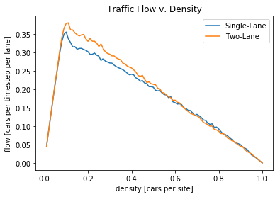

```python
#visualisation of two models over time
#density
densities=np.linspace(0.01,1,100) #array of different densities from 0 to 1
flow1=[]
flow2=[]
#loop through all densities multiple times, average flow, plot results
for d in densities:
    flow_temp1=[]
    flow_temp2=[]
    for j in range(100):
        sim1=run_sim(density=d, show=False, obj=True,n=100)
        flow_temp1.append(sim1.flow/100)
        sim2=run_sim2(density=d, show=False, obj=True,n=100)
        flow_temp2.append(sim2.flow/200)
    flow1.append(np.mean(flow_temp1))
    flow2.append(np.mean(flow_temp2))
plt.plot(densities,flow1, label="Single-Lane")
plt.plot(densities,flow2, label="Two-Lane")
plt.title("Traffic Flow v. Density")
plt.legend(loc='upper right')
plt.xlabel("density [cars per site]")
plt.ylabel("flow [cars per timestep per lane]")
plt.show()
```

The above graph illustrates the difference of flow per lane between the single-lane and two-lane models. We can see that the two-lane model is performing only marginally better, mostly between $0.1<density<0.5$.

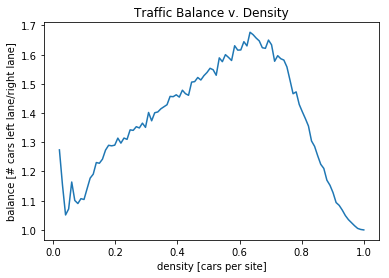

```python
#traffic balance left/right lane per density
balance=[]
densities=np.linspace(0.02,1,100)
for d in densities:
    balance_temp=[]
    for _ in range(50):
        sim=run_sim2(density=d,show=False,obj=True,n=100)
        balance_temp.append(np.mean(sim.balance))
    balance.append(np.mean(balance_temp))
plt.plot(densities,balance)
plt.title("Traffic Balance v. Density")
plt.xlabel("density [cars per site]")
plt.ylabel("balance [# cars left lane/right lane]")
plt.show()
```

Another measure I came up with to visualise the state of my model was Traffic Balance. This is simply a ratio of cars in the left lane over cars in the right lane. I plotted traffic balance over all densities and found the following interesting results:

I was curious to find out the source of this problem, and it turns out that the order of how lane change is actioned (initially left first, right second) affects balance. Actioning the lane change in a reverse order produces the opposite effect: low balances in mid densities.

It is interesting to observe, that despite coding my model to be symmetric such assumedly inconsequential details might affect the balance of traffic.

**#emergentproperties**: In this section I use a novel measure, traffic balance, to discover a behaviour of my model that is unexpected. This is an emergent property, the reasons for which I identify and explain above..

# Key Questions

How much more traffic can flow through a 2-lane road compared to a 1-lane road at the same traffic density? What about roads with more than 2 lanes? Either model 3 or more lanes and report on your results, or predict how much larger the traffic flow through a 3+ lane road will be compared to a 1-lane road at the same traffic density.

```python
## Three Lane Model
class TrafficSimulation3:

    def __init__(self, L=100, car_dens=0.3, prob_slow=0.5, max_speed=5, flow=0):
        self.length = L #size
        self.car_dens = car_dens #initial car density
        self.max_speed = max_speed #cap on speed
        self.prob_slow = prob_slow #prob cars will slow down at a step
        self.flow = 0
        self.balance = []

        #random indices for state initialisation
        init_ind1 = np.random.choice(range(self.length)
                                     , size=int(round(self.car_dens * self.length)), replace=False)
        init_ind2 = np.random.choice(range(self.length)
                                     , size=int(round(self.car_dens * self.length)), replace=False)
        init_ind3 = np.random.choice(range(self.length)
                                     , size=int(round(self.car_dens * self.length)), replace=False)

        #set up left lane
        self.state_left=-np.ones(self.length,dtype=int)
        self.state_left[init_ind1]=np.random.randint(0,self.max_speed+1,size=len(init_ind1))

        #set up middle lane
        self.state_middle=-np.ones(self.length,dtype=int)
        self.state_middle[init_ind2]=np.random.randint(0,self.max_speed+1,size=len(init_ind2))

        #set up right lane
        self.state_right=-np.ones(self.length,dtype=int)
        self.state_right[init_ind3]=np.random.randint(0,self.max_speed+1,size=len(init_ind3))


    def update_right(self,lane):
        #function carrying out rules from Part 1
        for i in range(self.length):
            if lane[i] != -1: #if car, i.e. not empty
                dist = 1
                while lane[(i + dist) % self.length] == -1:
                    dist += 1
                if lane[i] < self.max_speed:
                    lane[i] += 1
                if lane[i] >= dist:
                    lane[i] = dist - 1
                if (lane[i] > 0) and (np.random.uniform() < self.prob_slow):
                    lane[i] -= 1

        new_state = -np.ones(self.length, dtype=int)
        for i in range(self.length):
            if lane[i] != -1:
                new_state[(i + lane[i]) % self.length] = lane[i]
        self.state_right = new_state

    def update_left(self,lane):
        #function carrying out rules from Part 1
        for i in range(self.length):
            if lane[i] != -1: #if car, i.e. not empty
                dist = 1
                while lane[(i + dist) % self.length] == -1:
                    dist += 1
                if lane[i] < self.max_speed:
                    lane[i] += 1
                if lane[i] >= dist:
                    lane[i] = dist - 1
                if (lane[i] > 0) and (np.random.uniform() < self.prob_slow):
                    lane[i] -= 1

        new_state = -np.ones(self.length, dtype=int)
        for i in range(self.length):
            if lane[i] != -1:
                new_state[(i + lane[i]) % self.length] = lane[i]
        self.state_left = new_state

    def update_middle(self,lane):
        #function carrying out rules from Part 1
        for i in range(self.length):
            if lane[i] != -1: #if car, i.e. not empty
                dist = 1
                while lane[(i + dist) % self.length] == -1:
                    dist += 1
                if lane[i] < self.max_speed:
                    lane[i] += 1
                if lane[i] >= dist:
                    lane[i] = dist - 1
                if (lane[i] > 0) and (np.random.uniform() < self.prob_slow):
                    lane[i] -= 1

        new_state = -np.ones(self.length, dtype=int)
        for i in range(self.length):
            if lane[i] != -1:
                new_state[(i + lane[i]) % self.length] = lane[i]
        self.state_middle = new_state


    def step(self, show=True):
        #left lane
        for i in range(self.length):
            if self.state_left[i] != -1 and self.state_right[i]== -1: #if car but other lane empty
                #other car in the way?
                dist = 1
                while self.state_left[(i + dist) % self.length] == -1:
                    dist += 1
                if self.state_left[i] >=dist:
                    #check if space ahead in other lane
                    dist=1
                    while self.state_right[(i + dist) % self.length] == -1:
                        dist += 1
                    if self.state_left[i] <= dist:
                        #check if car behind in other lane has speed lower than where car would move
                        index=-1
                        while self.state_right[(i + index) % self.length] == -1:
                            index-=1
                        if self.state_right[i+index]-abs(index)<self.state_left[i]:
                            #move car to other lane
                            self.state_right[i]=self.state_left[i]
                            self.state_left[i]=-1

        #right lane
        for i in range(self.length):
            if self.state_right[i] != -1 and self.state_left[i]== -1: #if car but other lane empty
                #other car in the way?
                dist = 1
                while self.state_right[(i + dist) % self.length] == -1:
                    dist += 1
                if self.state_right[i] >=dist:
                    #check if space ahead in other lane
                    dist=1
                    while self.state_left[(i + dist) % self.length] == -1:
                        dist += 1
                    if self.state_right[i] <= dist:
                        #check if car behind has speed lower than where car would move
                        index=-1
                        while self.state_left[(i + index) % self.length] == -1:
                            index-=1
                        if self.state_left[i+index]-abs(index)<self.state_right[i]:
                            #move car to other lane
                            self.state_left[i]=self.state_right[i]
                            self.state_right[i]=-1

        #middle lane
        for i in range(self.length):
            if self.state_middle[i] != -1 and (self.state_left[i]== -1 or self.state_right[i]== -1): #if car but other lanes empty
                #other car in the way?
                dist = 1
                while self.state_middle[(i + dist) % self.length] == -1:
                    dist += 1
                if self.state_middle[i] >=dist:
                    #check how much space in other lanes
                    dist_left=1
                    while self.state_left[(i + dist_left) % self.length] == -1:
                        dist_left += 1
                    dist_right=1
                    while self.state_right[(i + dist_right) % self.length] == -1:
                        dist_right += 1

                    could_not_change=False

                    if self.state_middle[i] <= dist_left:
                        #try go left first
                        #check if car behind has speed lower than where car would move
                        index=-1
                        while self.state_left[(i + index) % self.length] == -1:
                            index-=1
                        if self.state_left[i+index]-abs(index)<self.state_middle[i]:
                            #move car to other lane
                            self.state_left[i]=self.state_middle[i]
                            self.state_middle[i]=-1
                        else:
                            could_not_change=True

                    if self.state_middle[i] <= dist_right and could_not_change:
                        #then try right
                        #check if car behind in other lane has speed lower than where car would move
                        index=-1
                        while self.state_right[(i + index) % self.length] == -1:
                            index-=1
                        if self.state_right[i+index]-abs(index)<self.state_middle[i]:
                            #move car to other lane
                            self.state_right[i]=self.state_middle[i]
                            self.state_middle[i]=-1

        #update both lanes according rules of one-lane simulation
        self.update_left(self.state_left)
        self.update_middle(self.state_middle)
        self.update_right(self.state_right)

        #update flow
        for k in range(5):
            if self.state_left[-k]+(self.length-k)>self.length:
                self.flow+=1
            if self.state_right[-k]+(self.length-k)>self.length:
                self.flow+=1
            if self.state_middle[-k]+(self.length-k)>self.length:
                self.flow+=1

        #display
        if show:
            self.show()

    def show(self):
        print(''.join('.' if x == -1 else str(x) for x in self.state_left))
        print(''.join('.' if x == -1 else str(x) for x in self.state_middle))
        print(''.join('.' if x == -1 else str(x) for x in self.state_right))
        print('')
```

**#heuristics**: In deciding how a car in the middle lane should choose whether to go left or right, when conditions are given to go either way, I chose to employ heuristic that is used by car drivers, that they first will try to change to the innermost lane for overtaking.

```python
# function for running sim multiple times
def run_sim3(length=100, density=0.3, p=0.5, max_speed=5,show=False, obj=False,n=50):
    sim = TrafficSimulation3(length, density, p)
    for _ in range(n):
        sim.step(show)
    #return object if needed
    if obj:
        return sim
```

### Density=0.3

```python
run_sim3(show=True,n=15)
```

```
0...2.00...3..1.1...100....3.....5.1..1..2.10.1.0.0...2.0.0.....40..2.00.1.....5.0...30....4......40
.1..2...........1....1......2..0..20.....5.10....3.00..2.1.......1...2.....3.0....3....0..1......0..
..2...1.1..1.10.....4...3..1.....3..0.......4...10....1......3.....400...3..1....0.1.0.0..2...2...2.

0.0.0.00.....2.1.1..000...2....4..1..2.1..10.10.0.0...0..1.1....00...10.10....3.10...0.1........5.00
...2..2..........1....1......1.0..0.1.....1..1...0.00...1.1........2...2......1......3.0....2.....1.
.3....0...20.0.1........4...1.....1..1.........300.....1........3..000....1...2..0.0..1.1....3..2...

0.0..10.1..1.0.0...200.1.....3..1...2.1.1...1.0..1.1..0...1.1...00...0.1..1.....20....1..2....1.0.00
2...1...2..........2...1.....0..1.0...2....1..1...10.1..0..1..........3...3....1.....0.0......2.....
....3.0.....1.1.1.........2...2.....2..2....2.100.1......2.......1.000...1..2..10.1.1..1..2........3

.10..00..1.0.0.0....00...2.....2.1..0.0...2.0..1.00.1..1..0..1..0.1..0...2.1...000......2...3..10.00
..2...2...2..........2...2...0...1.1.....3..1...2...1..20....2...........3...3..1....0..1........3..
..3..10.....0.0..1...2.......3..2.....2..2..0.000...2......2......100.1...1...2..1.1.1..1....3......

100..0.1.0..1.10....0.1.....3..0...2.1.1.0.10..0.00...2.1.0...1..1..2.1...1..2.000.........3..200.0.
.4...3..2....3.........2....3.1..0...2....1..1.....3..2.0.......3..........2...2..2..0....2.........
...1.00......10...1.....3.....1....3.....3...100.1....2......2....00.1.1....2...20.0..1...2.....3...

.0.1.0.0..1.0000.....1.1.....1.0...0..10..100.10.00..2.1.10....1..1..1.1..0..1.00.1.......0..2.00.0.
...2..1...2.....3.........3.....20......3..1..1.......0.0..........3..........3..2.1.0.......3......
.1.0.0.1.......1....2......3...1......3......40.1.1......3......3.0.1.1..2....1.00..1...2.....0...2.

..1.10..1.0.0000......1.1.....10.1..1.00.1.00.00.0.1...0.00.....1...20..1..1..100...2.....0..0.00.0.
.....2..2...2.......4.........4..0..........1..1......0.0..............4.......1.0.0..1..........4..
2.1.10..1.......1......3.....2...2.......3.1.0.1.1..2..2.....4..0.0..1..2..2..0.00...1.....3...1....

.10.00...10.0000.......1.1....0.1.1.0.0.10.00.0.10...2..100......1..0.1...2.1.00.1....2....1.0.00..1
..5...1...2...2..........5.....1.0...........1..1......1.1.................4...0.0..1..1............
..0.00....2......1.........4....3...3....0..10.0...2.1....3...1.0.0...1...2..20.00....1.......3..2..

100.0.1..00.0000........1.1....10.0.0.0.00.00.0...1.1...30.1......1.0...2.0..10.1.1.....2...10.00...
....2..1....2...2.............5.10............1..1.....0...2.................2..1.1...2.1...........
...10.1......3....1...........3...2.....4.1.00.0..2...1.0....30.0.0....1....200.00.....1.......1...2

00000...20.10000........0..1...0.10.0..10.100..1..0..1..00.0....3.0.0....20..0.1.1.1...1..2..0.0.1..
.....1..1.....2...2............1.0..............2..2....1....2.................2.1.1.....1..........
.2...1.1........3..1............2...2...0.0.00.0....2..1.1....0..1.1......2.000.00......1....1..1...

0000.1..1.1.0000...3....0....2..100..1.00.00.1...20...1.0.1.1....10..1...00...1.10..1...1...20.0..1.
......1...2.....2....3.........0.0................2..2....2.....3.................1..2.....2........
...2..1...2..2......1.............2...2.0.0.0.1.1....1.0...2...1.0...2....0.000.0.1......1....1...2.

0000...20..1000.1.....3..1.....2.00..0.0.100..1.0.0...0..1.1..2..0.1..1..00....100...1...1....1.1..1
.......1.....3.....3....3.......10..................2..2....2.......4..............1....3.....3.....
2....2.1...1...2......2..........1...3.1.1.1.1.1....30.0......3.10.....2...100.1.1.1......1.0...2...

000.10.0.1.0000..1......2.1....0.0.1..10.00.1.0..10...0...1.1..100...2.1.00..2.00.1...1...1...0...20
.........2.......4.....4....4....0....................2...3....3........4............2.....3.....3..
...3....1...1....2......2.......0..2.0.0.0.0..1.1...0.1.1......1..1.......3.0.1.10..1.....0.0......3

000.0.10..1000.1..1.....0...2...10...20.10.1.10.0..1..0....1..200.1....0.00...100..1....2...2..1..00
3...........3........4....3....3..1......................3....4...3..........5.........2......3.....
.2....3..1....2....2.......3....0...1.1.10.0...1...20..1.1......1...2...3.0..10.00...1.....1.1......

00.1.100.0.00.1..2..2....1....2.0.1..0.100..1..10....20.....1..00..1...0.0.1.000.1..1.....2..1...200
....4...........4.......3.....4..2..2........................4...3...3...........4.......2........4.
....3....3.1.....3...2........3..1...10.00.0.0...2.00...1..2..0..1.....3.10...0.00....1.....1..2....
```

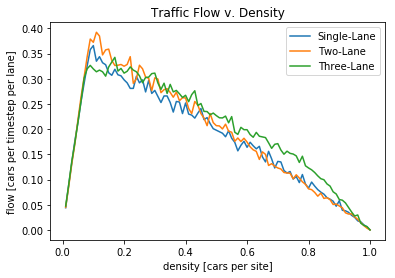

```python
#visualisation of three models over time
#density
densities=np.linspace(0.01,1,100) #array of different densities from 0 to 1
flow1=[]
flow2=[]
flow3=[]
#loop through all densities multiple times, average flow, plot results
for d in densities:
    flow_temp1=[]
    flow_temp2=[]
    flow_temp3=[]
    for j in range(10):
        sim1=run_sim(density=d, show=False, obj=True,n=100)
        flow_temp1.append(sim1.flow/100)
        sim2=run_sim2(density=d, show=False, obj=True,n=100)
        flow_temp2.append(sim2.flow/200)
        sim3=run_sim3(density=d, show=False, obj=True,n=100)
        flow_temp3.append(sim3.flow/300)
    flow1.append(np.mean(flow_temp1))
    flow2.append(np.mean(flow_temp2))
    flow3.append(np.mean(flow_temp3))
plt.plot(densities,flow1, label="Single-Lane")
plt.plot(densities,flow2, label="Two-Lane")
plt.plot(densities,flow3, label="Three-Lane")
plt.title("Traffic Flow v. Density")
plt.legend(loc='upper right')
plt.xlabel("density [cars per site]")
plt.ylabel("flow [cars per timestep per lane]")
plt.show()
```

## How applicable is this model to traffic in Berlin?

The multi-lane traffic models were constructed to be symmetric. That is, they don't follow a rule of "keeping right" or "keeping left". In Berlin, according to German traffic law, cars in unidirectional, multi-lane roads must keep to the right. That is, unless they want to overtake, they must be travelling in the right-most lane of the road. From this perspective it is true that this model does not realistically represent Berlin traffic.

However, in other ways it does. Most importantly, the patterns observed of traffic flow at different densities are similar to what I see day-to-day as I cycle. Especially that high densities of cars, eventually end up causing a traffic jam without there being an obstacle in the way to explain it. Thus the model can realistically represent aspects of human behaviour when driving.

**#utility**: In this section I identify in how closely the traffic models I constructed resemble real-life traffic in Berlin. I identify both similarities and differences to evaluate the utility of this model.